Álgebra Linear com Python

# Estudando a Biblioteca Matplotlib

#### Neste notebook, vamos analisar algumas funções pertencentes a biblioteca Matplotlib. É pertinente saber que tal biblioteca nos permite implementar ótimos gráficos e, através dela, reproduzir inúmeros dados de forma mais clara.

### Importando a biblioteca de funções matplotlib

```python
# importando a biblioteca de funções matplotlib do Python
import matplotlib.pyplot as plt
%matplotlib inline
```

### Função scatter

Vamos agora fazer uma plotagem do nosso primeiro gráfico usando a biblioteca de funções matplotlib pertencente a linguagem de programação Python.

Para se fazer um gráfico, precisamos de pelo menos coordenadas em nosso plano cartesiano. Para isso, devemos plotá-los individualmente:

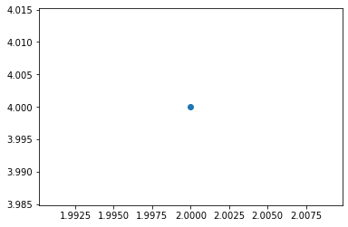

```python
# definindo a localização do ponto no eixo x
x = 2.0
# definindo a loclização do ponto no eixo y
y = 4.0
# plotando o ponto usando a função scatter
plt.scatter(x,y)
```

Ou então, podemos criar uma lista de coordenadas, de modo que podemos reduzir o nosso trabalha de plotar individualmente cada ponto a ser usado no nosso gráfico simples.

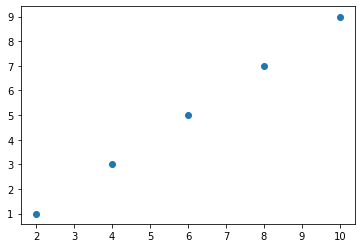

```python
# definindo a localização dos pontos no eixo x em nossa lista de coordenadas
x = [2.0, 4.0, 6.0, 8.0 , 10.0]
# definindo a localização dos pontos no eixo y em nossa lista de coordenadas
y = [1.0, 3.0, 5.0, 7.0, 9.0]
# plotando as listas de coordenadas para cada eixo usando a função scatter
plt.scatter(x,y)
```

Observe que na função scatter usamos dois padrões de entrada: **plt.scatter(lista do eixo x, lista do eixo y)**, de modo que teremos nossas coordenadas plotadas no padrão **(x,y)**. Podemos inverter as entradas de modo a obter nossas coordenadas **(y,x)** utilizando: **plt.scatter(lista do eixo y, lista do eixo x)**. Veja abaixo o gráfico plotado com as coordenadas **(y,x)** e compare com o gráfico acima com as coordenadas **(x,y)**.

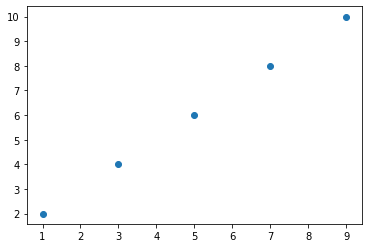

```python
# plotando as listas de coordenadas para cada eixo usando a função scatter
plt.scatter(y,x)
```

### Função plot

Vamos agora utilizar a mesma lista para plotar o nosso gráfico de outra forma. A função scatter plota unicamente todos os pontos informados a ela, mas há outra função que plota um gráfico que liga todos os pontos, na respectiva ordem informada, vamos utilizar a função **plot**.

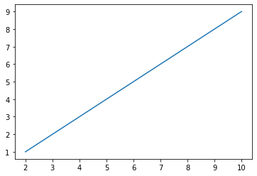

```python
# usando a função plot para ligar todos os pontos informados na lista
plt.plot(x,y)
```

Observe que o gráfico está corretamente obedecendo as nossas listas que formam as coordenadas **(x,y)**. Entretanto, o gráfico está com pouca personalização, fato esse que pode ser facilmente resolvido.

### Personalizando o gráfico

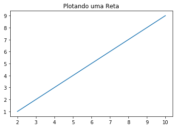

```python
# plotando o gráfico usando as listas feitas acima para obter as coordenadas (x,y)
plt.plot(x,y)
# adicionando um título ao nosso gráfico
plt.title("Plotando uma Reta")
```

É possível modificar a cor da reta plotada. Para fazer isso, devemos colocar uma terceira entrada na nossa função:

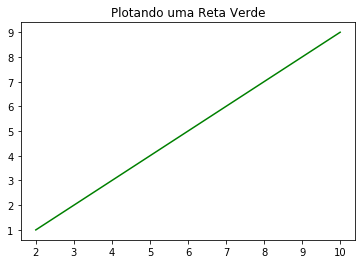

```python
# plotando o gráfico usando as listas feitas acima para obter as coordenadas (x,y)
# escolhendo a cor do gráfico usando uma terceira entrada de dados na função
plt.plot(x, y, color = "Green")
# adicionando um título ao nosso gráfico
plt.title("Plotando uma Reta Verde")
```

Também há a opção de se colocar uma grade ao nosso gráfico, de forma que podemos observar melhor a localização de cada ponto do mesmo:

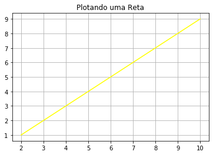

```python
# plotando o gráfico usando as listas feitas acima para obter as coordenadas (x,y)
# escolhendo a cor do gráfico usando uma terceira entrada de dados na função
plt.plot(x, y, color = "Yellow")
# adicionando um título ao nosso gráfico
plt.title("Plotando uma Reta")
# adicionando uma grade ao gráfico
plt.grid(True)
```

Do mesmo modo, temos uma caixa preta que moldura todo o gráfico. Há a opção de remové-la do nosso gráfico, dependendo do gosto do usuário:

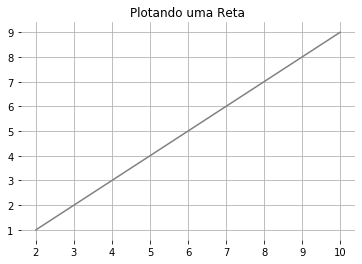

```python
# plotando o gráfico usando as listas feitas acima para obter as coordenadas (x,y)
# escolhendo a cor do gráfico usando uma terceira entrada de dados na função
plt.plot(x, y, color = "Gray")
# adicionando um título ao nosso gráfico
plt.title("Plotando uma Reta")
# adicionando uma grade ao gráfico
plt.grid(True)
# removendo a moldura do gráfico
plt.box(False)
```

Essas personalizações não estão unicamente restritas a função plot. Também podemos utilizá-las em outras funções, como a scatter ou outras que vamos apresentar a vocês mais adiante.

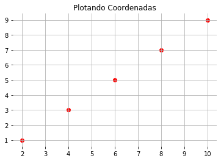

```python
# plotando o gráfico usando as listas feitas acima para obter as coordenadas (x,y)
# escolhendo a cor do gráfico usando uma terceira entrada de dados na função
plt.scatter(x, y, color = "Red")
# adicionando um título ao nosso gráfico
plt.title("Plotando Coordenadas")
# adicionando uma grade ao gráfico
plt.grid(True)
# removendo a moldura do gráfico
plt.box(False)
```

Caso seja pertinente, é possível também ocultar os valores de cada eixo:

```
([], <a list of 0 Text yticklabel objects>)
```

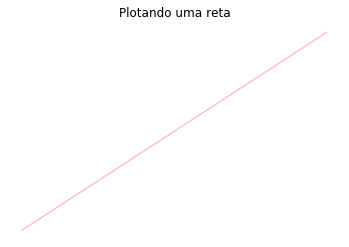

```python
# plotando o gráfico usando as listas feitas acima para obter as coordenadas (x,y)
# escolhendo a cor do gráfico usando uma terceira entrada de dados na função
plt.plot(x, y, color = "Pink")
# adicionando um título ao nosso gráfico
plt.title("Plotando uma reta")
# adicionando uma grade ao gráfico
plt.grid(True)
# removendo a moldura do gráfico
plt.box(False)
# removendo os valores do eixo x usando a função xticks
plt.xticks([],[])
# removendo os valores do eixo y usando a função xticks
plt.yticks([],[])
```

### Legendas

Um outro recurso que pode ser de grande ajuda para leitura dos gráficos, são as legendas. Nela podemos informar uma breve descrição sobre o que tal gráfico legendado está representando.

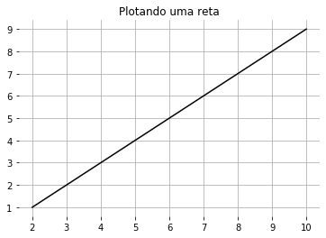

```python
# plotando o gráfico usando as listas feitas acima para obter as coordenadas (x,y)
# escolhendo a cor do gráfico usando uma terceira entrada de dados na função
# adicionando uma legenda ao gráfico usando uma quarta entrada de dados na função
plt.plot(x, y, color = "Black", label = " Exemplo de legenda para descrever o que a reta representa")
# adicionando um título ao nosso gráfico
plt.title("Plotando uma reta")
# adicionando uma grade ao gráfico
plt.grid(True)
# removendo a moldura do gráfico
plt.box(False)
```

Observe que tivemos um problema: a legenda não apareceu. Isso ocorre porque ainda não foi colocado o comando que plota as legendas em si, apenas a definimos na função plot. Veja abaixo como organizar isso:

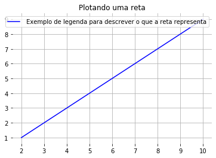

```python
# plotando o gráfico usando as listas feitas acima para obter as coordenadas (x,y)
# escolhendo a cor do gráfico usando uma terceira entrada de dados na função
# adicionando uma legenda ao gráfico usando uma quarta entrada de dados na função
plt.plot(x, y, color = "Blue", label = " Exemplo de legenda para descrever o que a reta representa")
# adicionando um título ao nosso gráfico
plt.title("Plotando uma reta")
# adicionando uma grade ao gráfico
plt.grid(True)
# removendo a moldura do gráfico
plt.box(False)
# adicionando a legenda ao gráfico
plt.legend()
```

Para melhorar o nosso gráfico, devemos observar que a legenda é grande demais para o espaço utilizado. Vamos agora aprender a colocar as dimensões em nosso gráfico.

### Altura e largura do gráfico

Vamos continuar plotando o mesmo gráfico que estamos trabalhando, mas agora vamos organizar as suas dimensões de modo que ele fique maior ou menor.

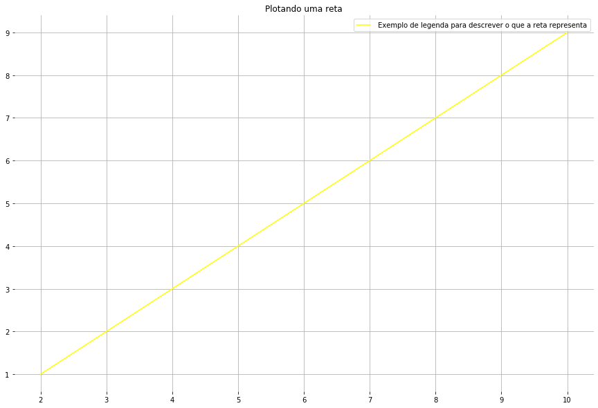

```python
# definindo as dimensões do gráfico
plt.figure(figsize = (15,10))
# plotando o gráfico usando as listas feitas acima para obter as coordenadas (x,y)
# escolhendo a cor do gráfico usando uma terceira entrada de dados na função
# adicionando uma legenda ao gráfico usando uma quarta entrada de dados na função
plt.plot(x, y, color = "Yellow", label = " Exemplo de legenda para descrever o que a reta representa")
# adicionando um título ao nosso gráfico
plt.title("Plotando uma reta")
# adicionando uma grade ao gráfico
plt.grid(True)
# removendo a moldura do gráfico
plt.box(False)
# adicionando a legenda ao gráfico
plt.legend()
```

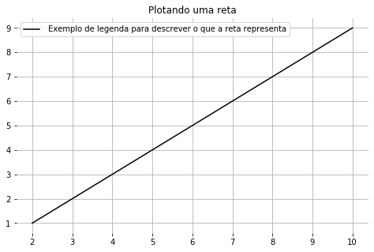

```python
# definindo as dimensões do gráfico
plt.figure(figsize = (8,5))
# plotando o gráfico usando as listas feitas acima para obter as coordenadas (x,y)
# escolhendo a cor do gráfico usando uma terceira entrada de dados na função
# adicionando uma legenda ao gráfico usando uma quarta entrada de dados na função
plt.plot(x, y, color = "Black", label = " Exemplo de legenda para descrever o que a reta representa")
# adicionando um título ao nosso gráfico
plt.title("Plotando uma reta")
# adicionando uma grade ao gráfico
plt.grid(True)
# removendo a moldura do gráfico
plt.box(False)
# adicionando a legenda ao gráfico
plt.legend()
```

### Dois gráficos em um só

Podemos plotar dois gráfico em um só. Para visualizar isso, vamos criar uma situação abaixo em que uma empresa de celulares de nome Viciocell tem três marcas de produtos e, para cada uma delas, foi obtido os valores gastos na produção mês a mês. Devemos colocar todos esses dados em um gráfico, de forma que seja possível analisar melhor todo o rendimento da empresa durante o ano.

```python
# gastos com o celular da marca ApplePhone mês a mês, em milhares de reais, respectivamente
ApplePhone = [8.3, 9.6, 20.9, 18.1, 5.0, 24.9, 35.2, 30.1, 10.7, 8.7, 8.3, 13.1]
```

```python
# gastos com o celular da marca XionesPhone mês a mês, em milhares de reais, respectivamente
XionesPhone = [4.1, 4.2, 10.3, 10.0, 3.6, 14.7 , 30.2, 10.9, 6.8, 2.3, 4.2, 12.7]
```

```python
# gastos com o celular da marca BikecholaPhone mês a mês, em milhares de reais, respectivamente
BikecholaPhone = [1.0, 4.5, 7.8, 3.7, 7.8, 20.0, 39.0, 12.0, 14.5, 3.7, 2.2, 1.1]
```

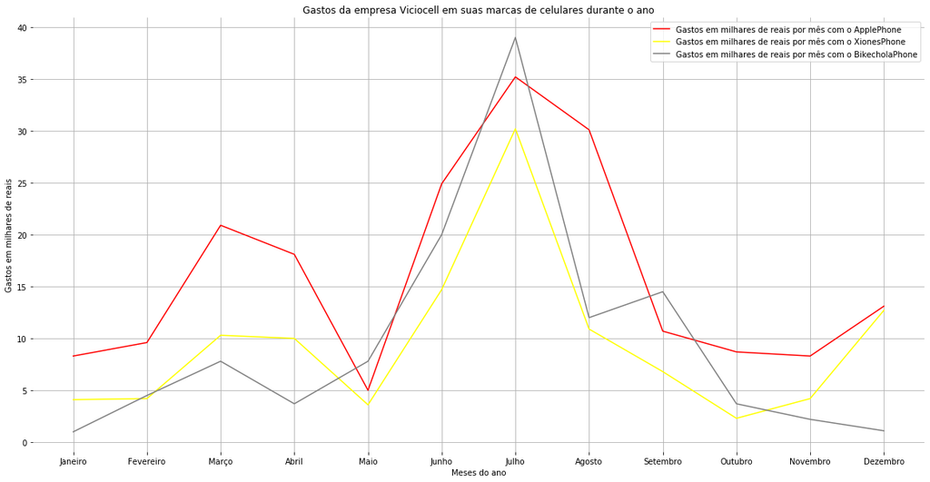

```python
# definindo uma lista com os meses do ano
meses = ["Janeiro", "Fevereiro", "Março", "Abril", "Maio", "Junho", "Julho", "Agosto", "Setembro",
        "Outubro", "Novembro", "Dezembro"]
# definindo as dimensões do gráfico
plt.figure(figsize = (20,10))
# plotando o primeiro gráfico relativo aos gastos com o ApplePhone
plt.plot(meses, ApplePhone, color = "Red", label = "Gastos em milhares de reais por mês com o ApplePhone")
# plotando o segundo gráfico relativo aos gastos com o XionesPhone
plt.plot(meses, XionesPhone, color = "Yellow",
         label = "Gastos em milhares de reais por mês com o XionesPhone")
# plotando o terceiro gráfico relativo aos gastos com o BikecholaPhone
plt.plot(meses, BikecholaPhone, color = "Gray",
         label = "Gastos em milhares de reais por mês com o BikecholaPhone")
# plotando o título do gráfico
plt.title("Gastos da empresa Viciocell em suas marcas de celulares durante o ano")
# adicionando uma grade ao gráfico
plt.grid(True)
# removendo a moldura do gráfico
plt.box(False)
# adicionando as legendas do gráfico
plt.legend()
# adicionando uma legenda ao eixo x
plt.xlabel("Meses do ano")
# adicionando uma legenda ao eixo y
plt.ylabel("Gastos em milhares de reais")
```

### Gráficos a partir de funções

Podemos representar gráficos utilizando as funções que as representam. Dessa forma, poderemos ter uma ferramenta mais potente ainda de gerar gráficos.

Vamos considerar a seguinte função: $$f(x) = x^{2}sen(\frac{1}{x})$$

e para isso, devemos usar algumas funções da biblioteca numpy, já apresentadas em um progama anterior.

```python
# importando as funções da biblioca numpy do Python
import numpy as np
```

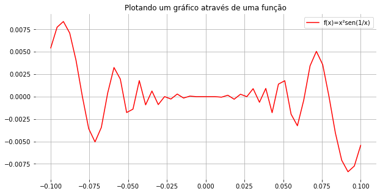

```python
# definindo as dimensões do gráfico
plt.figure(figsize = (10,5))
# definindo valores para a variável x entre -1 e 1
valoresX = np.linspace(-0.10, 0.10)
# plotando o gráfico cuja função está descrita acima
plt.plot(valoresX, (valoresX ** 2) * np.sin(1 / valoresX), color = "Red", label = "f(x)=x²sen(1/x)")
# adicionando um título ao gráfico
plt.title("Plotando um gráfico através de uma função")
# adicionando uma grade ao gráfico
plt.grid(True)
# removendo a moldura do gráfico
plt.box(False)
# adicionando a legenda ao gráfico
plt.legend()
```

### Outros tipos de gráficos

- **Gráfico de Barras (função bar)**

Vamos plotar um gráfico de barras, para isso, vamos hipotetizar uma situação em que teremos a quantidade de horas de estudo que um universitário deve dedicar por dia para aprender bem as disciplinas no curso de engenharia elétrica da UFCG.

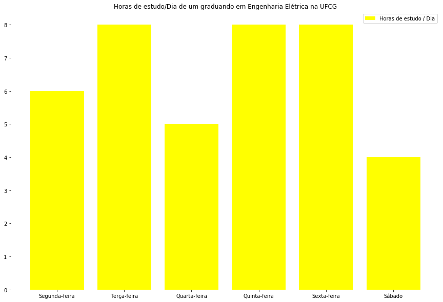

```python
# definindo em uma lista os dias da semana que irão aparecer no eixo x
dias = ["Segunda-feira", "Terça-feira", "Quarta-feira", "Quinta-feira", "Sexta-feira", "Sábado"]
# definindo em uma lista as horas de estudo a serem dedicadas de segunda a sábado, respectivamente
horas = [6.0, 8.0, 5.0, 8.0, 8.0, 4.0]
# definindo as dimensões do nosso gráfico
plt.figure(figsize = (15,10))
# plotando o nosso gráfico de barras
plt.bar(dias, horas, color = "Yellow", label = "Horas de estudo / Dia")
# Removendo a grade ao gráfico
plt.grid(False)
# removendo a moldura do gráfico
plt.box(False)
# adicionando um título ao gráfico
plt.title("Horas de estudo/Dia de um graduando em Engenharia Elétrica na UFCG")
# adicionando a legenda ao gráfico
plt.legend()
```

- **Gráfico de Pizza (função pie)**

Vamos plotar um gráfico no estilo "pizza", usando os mesmos dados anteriores.

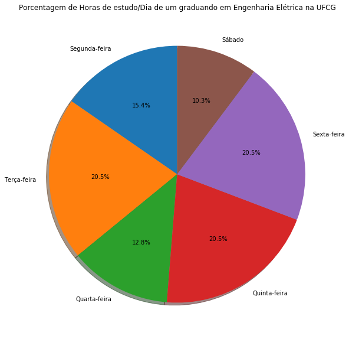

```python
# definindo as dimensões do gráfico
plt.figure(figsize = (15,10))
# plotando o gráfico de pizza, com as legendas, o formato da porcentagem, com sombras ativadas e iniciando
# com o primeiro traço entre os pedaços de informações em 90°
plt.pie(horas, labels = dias, autopct = '%1.1f%%', shadow = True, startangle = 90)
# definindo o título do nosso gráfico
plt.title("Porcentagem de Horas de estudo/Dia de um graduando em Engenharia Elétrica na UFCG")
```

### Alguma Dúvida? Entre em Contato Comigo:

- Me envie um e-mail;